# DATA 608 – Knowledge and Visual Analytics: Assignment 1

Amber Ferger

9/6/2020

**Principles of Data Visualization and Introduction to ggplot2**

I have provided you with data about the 5,000 fastest growing companies in the US, as compiled by Inc. magazine. lets read this in:

```r
inc <- read.csv("https://raw.githubusercontent.com/charleyferrari/CUNY_DATA_608/master/module1/Data/inc5000_data.csv", header= TRUE)
```

And lets preview this data:

```r
head(inc)
```

```
##   Rank                         Name Growth_Rate   Revenue
## 1    1                         Fuhu      421.48 1.179e+08
## 2    2        FederalConference.com      248.31 4.960e+07
## 3    3                The HCI Group      245.45 2.550e+07
## 4    4                      Bridger      233.08 1.900e+09
## 5    5                       DataXu      213.37 8.700e+07
## 6    6 MileStone Community Builders      179.38 4.570e+07
##                       Industry Employees         City State
## 1 Consumer Products & Services       104   El Segundo    CA
## 2          Government Services        51     Dumfries    VA
## 3                       Health       132 Jacksonville    FL
## 4                       Energy        50      Addison    TX
## 5      Advertising & Marketing       220       Boston    MA
## 6                  Real Estate        63       Austin    TX
```

```r
summary(inc)
```

```
##       Rank          Name            Growth_Rate         Revenue
##  Min.   :   1   Length:5001        Min.   :  0.340   Min.   :2.000e+06
##  1st Qu.:1252   Class :character   1st Qu.:  0.770   1st Qu.:5.100e+06
##  Median :2502   Mode  :character   Median :  1.420   Median :1.090e+07
##  Mean   :2502                      Mean   :  4.612   Mean   :4.822e+07
##  3rd Qu.:3751                      3rd Qu.:  3.290   3rd Qu.:2.860e+07
##  Max.   :5000                      Max.   :421.480   Max.   :1.010e+10
##
##    Industry           Employees           City              State
##  Length:5001        Min.   :    1.0   Length:5001        Length:5001
##  Class :character   1st Qu.:   25.0   Class :character   Class :character
##  Mode  :character   Median :   53.0   Mode  :character   Mode  :character
##                     Mean   :  232.7
##                     3rd Qu.:  132.0
##                     Max.   :66803.0
##                     NA's   :12
```

Think a bit on what these summaries mean. Use the space below to add some more relevant non-visual exploratory information you think helps you understand this data:

**Top Industries by Total Revenue:**

```r
# distinct industries
inc %>%
  summarize(DISTINCT_INDUSTRIES = n_distinct(Industry))
```

```
##   DISTINCT_INDUSTRIES
## 1                  25
```

```r
sum1 <- inc %>%
  group_by(Industry) %>%
  summarize(NUM_COMPANIES = n(),
            PCT_TOTAL_COMPANIES = n()/nrow(.),
            INDUSTRY_REVENUE = sum(Revenue),
            PCT_TOTAL_REVENUE = sum(Revenue)/ sum(inc$Revenue),
            INDUSTRY_EMPLOYEES = sum(Employees, na.rm = TRUE))

# top 10 industries
kable(
  sum1 %>%
    arrange(desc(INDUSTRY_REVENUE)) %>%
    top_n(.,10)
)
```

| Industry | NUM_COMPANIES | PCT_TOTAL_COMPANIES | INDUSTRY_REVENUE | PCT_TOTAL_REVENUE | INDUSTRY_EMPLOYEES |
| --- | --- | --- | --- | --- | --- |
| Business Products & Services | 482 | 0.0963807 | 26367900000 | 0.1093374 | 117357 |
| IT Services | 733 | 0.1465707 | 20681300000 | 0.0857573 | 102788 |
| Health | 355 | 0.0709858 | 17863400000 | 0.0740725 | 82430 |
| Consumer Products & Services | 203 | 0.0405919 | 14956400000 | 0.0620183 | 45464 |
| Financial Services | 260 | 0.0519896 | 13150900000 | 0.0545316 | 47693 |
| Food & Beverage | 131 | 0.0261948 | 12911300000 | 0.0535381 | 65911 |
| Manufacturing | 256 | 0.0511898 | 12684000000 | 0.0525956 | 43942 |
| Human Resources | 196 | 0.0391922 | 9246100000 | 0.0383400 | 226980 |
| Software | 342 | 0.0683863 | 8140600000 | 0.0337559 | 51262 |
| Security | 73 | 0.0145971 | 3812800000 | 0.0158102 | 41059 |

- There are 25 distinct industries in the data set.
- The top industry by total revenue is Business Products & Services, which accounts for ~9.6% of the top 5000 companies and ~11% of the total revenue.
- Three of the top 10 industries relate to tech and security.

**Top States by Total Revenue:**

```r
sum2 <- inc %>%
  group_by(State) %>%
  summarize(NUM_COMPANIES = n(),
            PCT_TOTAL_COMPANIES = n()/nrow(.),
            INDUSTRY_REVENUE = sum(Revenue),
            PCT_TOTAL_REVENUE = sum(Revenue)/ sum(inc$Revenue),
            INDUSTRY_EMPLOYEES = sum(Employees, na.rm = TRUE))

# top 5 states
kable(
  sum2 %>%
  arrange(desc(INDUSTRY_REVENUE)) %>%
  top_n(.,5)
)
```

| State | NUM_COMPANIES | PCT_TOTAL_COMPANIES | INDUSTRY_REVENUE | PCT_TOTAL_REVENUE | INDUSTRY_EMPLOYEES |
| --- | --- | --- | --- | --- | --- |
| IL | 273 | 0.0545891 | 33244300000 | 0.1378511 | 103266 |
| CA | 701 | 0.1401720 | 23457900000 | 0.0972707 | 161219 |
| TX | 387 | 0.0773845 | 22164200000 | 0.0919063 | 90765 |
| NY | 311 | 0.0621876 | 18260400000 | 0.0757187 | 84370 |
| DE | 16 | 0.0031994 | 676800000 | 0.0028064 | 68544 |

- The top state by revenue is Illinois, and it accounts for almost 42% more revenue and less than half the number of companies than the second highest state, California.
- Only ~5% of the total companies come from Illinois, but they account for almost 14% of the total revenue.

## Question 1

Create a graph that shows the distribution of companies in the dataset by State (ie how many are in each state). There are a lot of States, so consider which axis you should use. This visualization is ultimately going to be consumed on a ‘portrait’ oriented screen (ie taller than wide), which should further guide your layout choices.

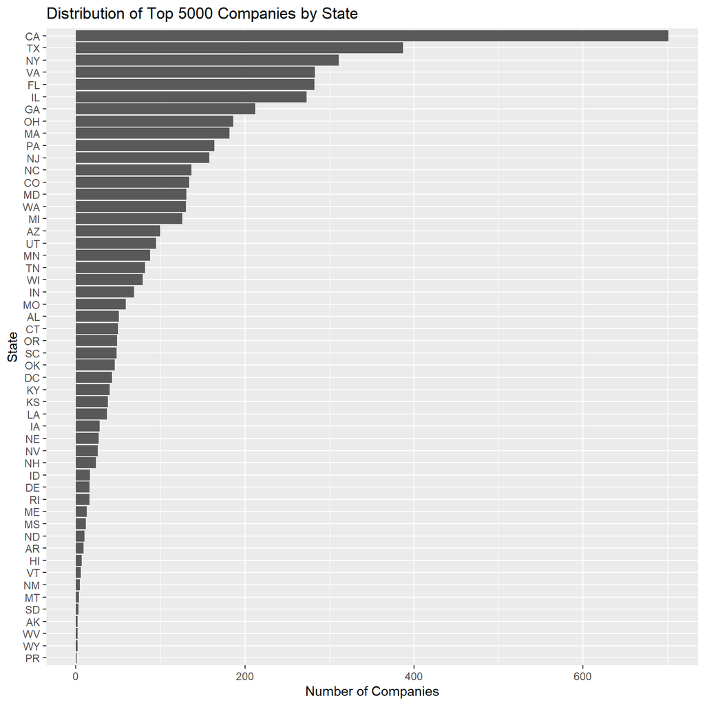

```r
p <- ggplot(inc, aes(x=fct_rev(fct_infreq(State)))) +
  geom_histogram(stat="count") +
  ggtitle("Distribution of Top 5000 Companies by State") +
  xlab("State") + ylab("Number of Companies") +
  coord_flip()

p
```

## Question 2

Lets dig in on the state with the 3rd most companies in the data set. Imagine you work for the state and are interested in how many people are employed by companies in different industries. Create a plot that shows the average and/or median employment by industry for companies in this state (only use cases with full data, use R’s `complete.cases()` function.) In addition to this, your graph should show how variable the ranges are, and you should deal with outliers.

**First, let’s subset our data to state with the 3rd most companies. We’ll also eliminate any records that have null values. We can see that the state we’re working with is NY:**

```r
thirdState <- inc %>%
  add_count(State) %>%
  arrange(desc(n)) %>%
  filter(State == unique(State)[3]) %>%
  select(-n)

thirdState <- thirdState[complete.cases(thirdState), ]

unique(thirdState$State)
```

```
## [1] "NY"
```

**Next, let’s take a look at each Industry separately. This will help us to identify any outliers (dots above or below the body of the boxplot). We can see that many of the Industries have some outliers in the dataset.**

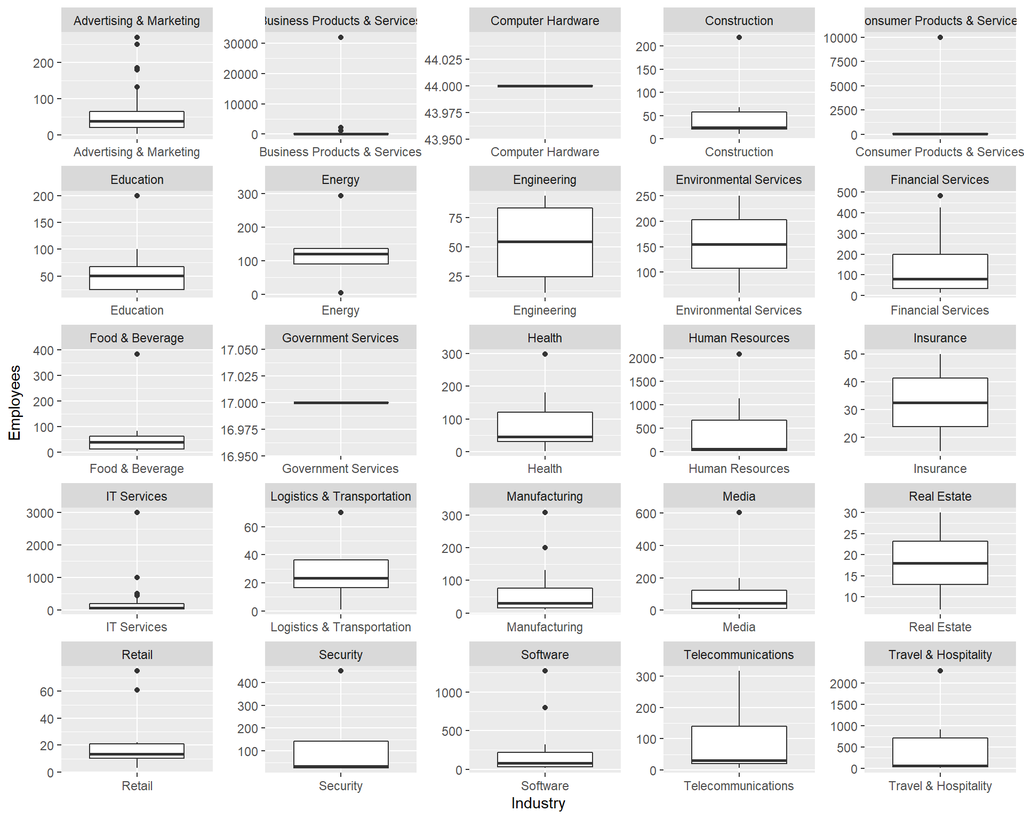

```r
vals <- ggplot(thirdState %>% filter(complete.cases(.) == TRUE), aes(x=Industry, y=Employees)) +
    geom_boxplot() +
  facet_wrap(~Industry, scale="free")

vals
```

**Now we will define a function to remove the outliers from each Industry separately and apply it to our dataframe. We can confirm that our outliers are removed by checking the rowcounts of the original NY dataset to the new dataset.**

```r
# function to remove outliers
removeOutliers <- function(df){
  outliers <- boxplot.stats(df$Employees)$out
  df <- df %>%
    filter(!Employees %in% outliers)
  return(df)
}

# group data into separate dataframes based on Industry
groupedData <- thirdState %>%
  group_by(Industry) %>%
  group_split()

# apply removeOutliers function to dataframe
finalData <- do.call("rbind", lapply(groupedData, removeOutliers))

paste0('Num rows in original dataset: ', nrow(thirdState), ' | Num rows in new dataset: ', nrow(finalData))
```

```
## [1] "Num rows in original dataset: 311 | Num rows in new dataset: 280"
```

**Finally, we can create a plot that shows the average employment by industry:**

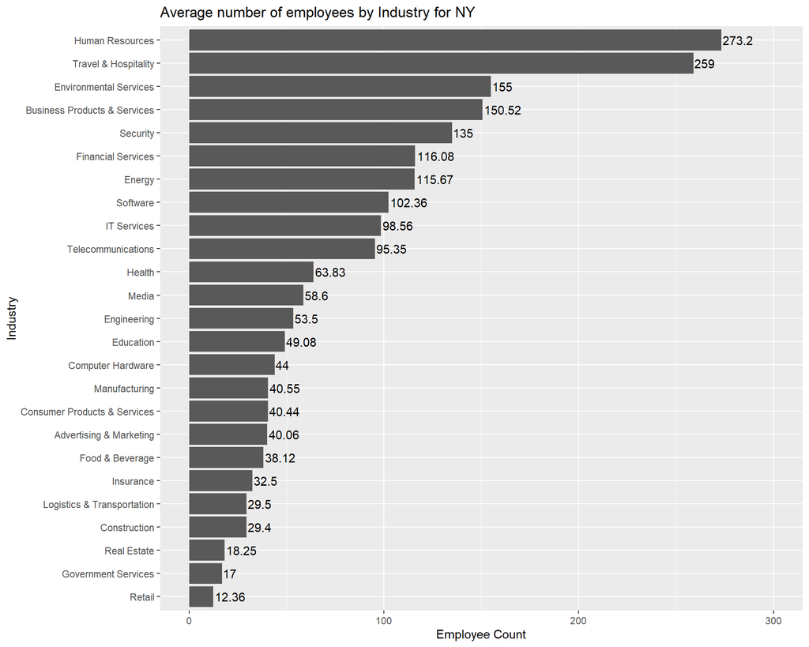

```r
ggplot(finalData, aes(x=reorder(Industry, Employees, mean), y=Employees)) +
  stat_summary(fun="mean", geom="bar") +
  ggtitle(paste0("Average number of employees by Industry for ",unique(finalData$State))) +
  xlab("Industry") + ylab("Employee Count") +
  coord_flip() +
  stat_summary(aes(label=round(..y..,2)), fun=mean, geom="text", vjust = 0.5, hjust = -0.05) +
  expand_limits(y = 300)
```

**And similarly, we can create a plot that shows the median employment by industry:**

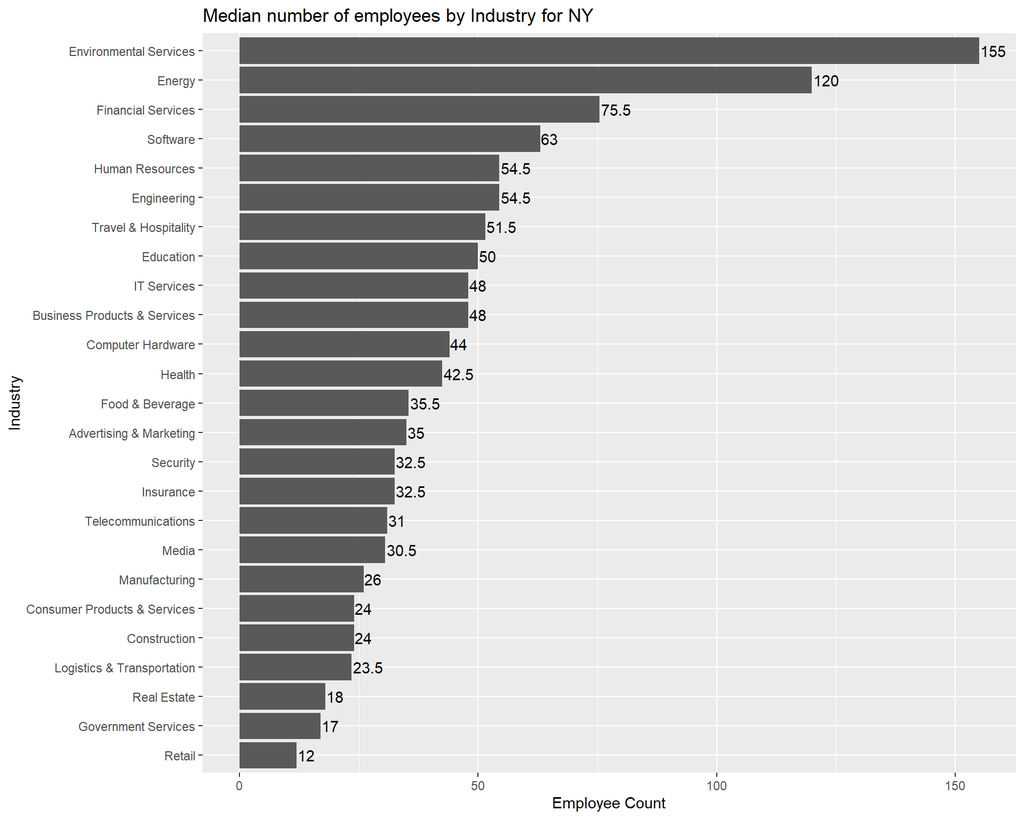

```r
# median
ggplot(finalData, aes(x=reorder(Industry, Employees, median), y=Employees)) +
  stat_summary(fun="median", geom="bar") +
  ggtitle(paste0("Median number of employees by Industry for ",unique(finalData$State))) +
  xlab("Industry") + ylab("Employee Count") +
  coord_flip() +
  stat_summary(aes(label=round(..y..,2)), fun=median, geom="text", vjust = 0.5, hjust = -0.05)
```

## Question 3

Now imagine you work for an investor and want to see which industries generate the most revenue per employee. Create a chart that makes this information clear. Once again, the distribution per industry should be shown.

**First, we can group our data by Industry and calculate the revenue by employee:**

```r
revByEmployee <- inc %>%
  group_by(Industry) %>%
  summarize(TOTAL_REVENUE = sum(Revenue, na.rm=TRUE),
            TOTAL_EMPLOYEES = sum(Employees, na.rm = TRUE),
            REV_PER_EMPLOYEE = sum(Revenue, na.rm=TRUE)/ sum(Employees, na.rm = TRUE)) %>%
  arrange(desc(REV_PER_EMPLOYEE)) %>%
  ungroup()

revByEmployee
```

```
## # A tibble: 25 x 4
##    Industry                     TOTAL_REVENUE TOTAL_EMPLOYEES REV_PER_EMPLOYEE
##    <chr>                                <dbl>           <int>            <dbl>
##  1 Computer Hardware              11885700000            9714         1223564.
##  2 Energy                         13771600000           26437          520921.
##  3 Construction                   13174300000           29099          452741.
##  4 Logistics & Transportation     14840500000           39994          371068.
##  5 Consumer Products & Services   14956400000           45464          328972.
##  6 Insurance                       2337900000            7339          318558.
##  7 Manufacturing                  12684000000           43942          288653.
##  8 Retail                         10257400000           37068          276718.
##  9 Financial Services             13150900000           47693          275741.
## 10 Environmental Services          2638800000           10155          259852.
## # ... with 15 more rows
```

**Now, we can plot this information:**

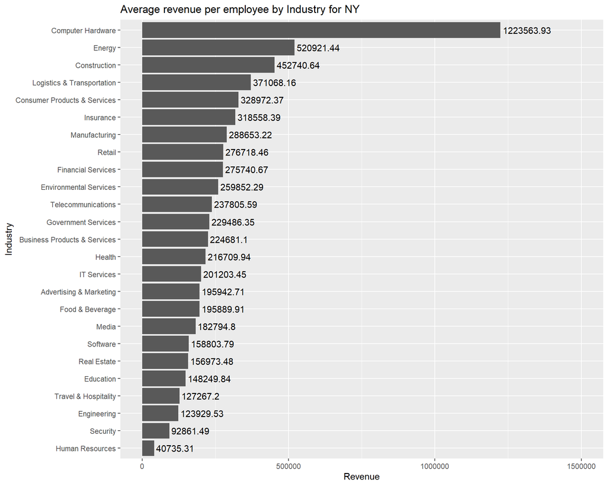

```r
ggplot(revByEmployee, aes(x=reorder(Industry, REV_PER_EMPLOYEE), y=REV_PER_EMPLOYEE)) +
  geom_bar(stat="identity") +
  ggtitle(paste0("Average revenue per employee by Industry for ",unique(finalData$State))) +
  xlab("Industry") + ylab("Revenue") +
  coord_flip() +
  stat_summary(aes(label=round(..y..,2)), geom="text", vjust = 0.5, hjust = -0.05) +
  expand_limits(y = 1500000)
```